# Explore PRMC Score - How To Make Graphics

Layla Bouzouki

7/12/2019

## How to Create the PRMC Scoring Graphics

### Data

This document goes through the step by step of how the PRMC scoring graphics were created.

For reference here is what I’m talking about: http://10.64.183.96:3939/LB_explore_prmcScore/.

Let’s continue…

First, we need some data. For these graphs, I used the *theRatesByCounty_df*. This dataframe includes the age-adjusted incidence rates, counts, and percent late stage at diagnosis for every combination of geography, race/ethnicity (NHW, NHB, Hispanic, all), and lifestage (youth, adult, senior, all).

theRatesByCounty_df

| crudeRate | adjRate | lci | uci | site | siteNum | place_num | sex | race | count | ratePop | pop | lifeStage | pLateStage | place |
| --- | --- | --- | --- | --- | --- | --- | --- | --- | --- | --- | --- | --- | --- | --- |
| 2124.22 | 2130.03 | 2055.19 | 2207.01 | All | 0 | 1 | P | All_Races | 3104 | 29225 | 31895 | Senior | 0.4391108 | Alachua County |
| 336.99 | 357.99 | 344.19 | 372.27 | All | 0 | 1 | P | All_Races | 2733 | 162199 | 161909 | Adult | 0.4548116 | Alachua County |
| 19.13 | 18.45 | 13.87 | 24.20 | All | 0 | 1 | P | All_Races | 58 | 60652 | 62777 | Youth | 0.5689655 | Alachua County |
| 467.72 | 484.55 | 471.98 | 497.40 | All | 0 | 1 | P | All_Races | 5895 | 252076 | 256581 | All | 0.4476675 | Alachua County |
| 1226.04 | 1252.24 | 974.98 | 1592.43 | All | 0 | 1 | P | Hispanic | 71 | 1158 | 1326 | Senior | 0.4788732 | Alachua County |
| 125.21 | 207.45 | 165.72 | 256.65 | All | 0 | 1 | P | Hispanic | 90 | 14376 | 14416 | Adult | 0.4777778 | Alachua County |
| NaN | NaN | NaN | NaN | All | 0 | 1 | P | Hispanic | NaN | 6486 | 7337 | Youth | NaN | Alachua County |
| 152.58 | 285.88 | 242.11 | 336.78 | All | 0 | 1 | P | Hispanic | 168 | 22021 | 23079 | All | 0.4761905 | Alachua County |
| 2035.59 | 2067.90 | 1872.33 | 2279.43 | All | 0 | 1 | P | NHB | 421 | 4136 | 4529 | Senior | 0.4608076 | Alachua County |
| 349.59 | 367.12 | 335.99 | 400.73 | All | 0 | 1 | P | NHB | 531 | 30379 | 30667 | Adult | 0.5216573 | Alachua County |

```r
library(tidyverse)
# read in fcds rate data
load("../../Box Sync/cancerBurden/data/theRatesByCounty_df.rda")

# I only want to look at Sylvester catchment area
sylRates <- theRatesByCounty_df %>%
   filter(place_num == 888)

# I don't care about a particular lifestage nor do I care about all cancers as a
# whole or other cancers aside from the 19 we've marked as important
prevalence <- sylRates %>%
  filter(lifeStage == "All", !site %in% c("All","Other")) %>%
  #also, for the sake of the graphics, I want the percentage to be pretty
  mutate(pLateStage = round(pLateStage*100,1))
```

### It Started With a Plot…

I wanted to start off by showing the counts for the 19 different cancers for all races

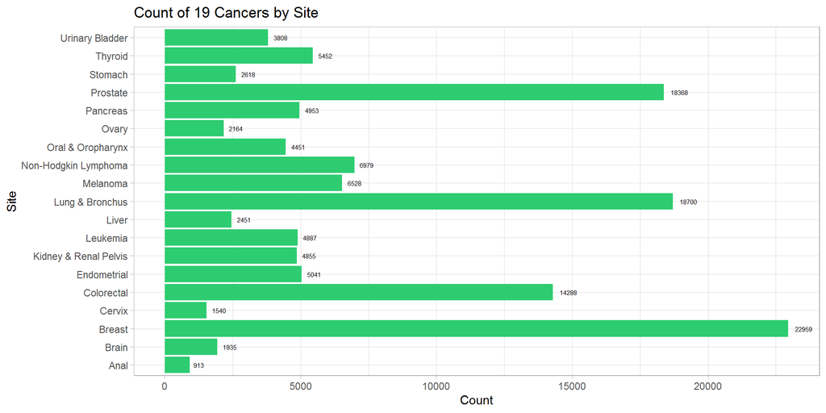

```r
x <- prevalence %>%
  filter(sex == "P")  #sex == "people"

f <- filter(x, race == "All_Races") %>%
  ggplot(aes(x = site, y = count))

f + geom_bar(position = "dodge", stat = "identity", fill = "#2ECC71") +
  coord_flip() +
  geom_text(aes(label = count), hjust = -0.4, color = "black",
            position = position_dodge(width = 1), size = 2) +
  labs(x = "Site",
       y = "Count") +
  ggtitle("Count of 19 Cancers by Site") +
  theme_light()
```

That’s cool but, I want to order this by most frequent to less frequent so that means I need to make site a factor and because there are 4 different race/ethnicity categories, I also need to make sure each race has it’s own order. Therefore, I need to `group_by()` race and `arrange()` by race and count.

```r
x <- prevalence %>%
  filter(sex == "P") %>%   # sex == "people"
  group_by(race) %>%
  arrange(race, count) %>%
  mutate(site = factor(site, levels = unique(site)))

f <- filter(x, race == "All_Races") %>%
  ggplot(aes(x = site, y = count))

f + geom_bar(position = "dodge", stat = "identity", fill = "#2ECC71") +
  coord_flip() +
  geom_text(aes(label = count), hjust = -0.4, color = "black",
            position = position_dodge(width = 1), size = 2) +
  labs(x = "Site",
       y = "Count") +
  ggtitle("Count of 19 Cancers by Site") +
  theme_light()
```

[output not shown]

**Yippee!!**

That’s 15 different plots and if you know me, there’s no way in hell I am copying and pasting this crap 15 times…

Red rover, red rover, please send a function right over :)

This didn’t seem *terribly* intimidating at first, the only arguments I needed was which measure I wanted to plot: count, adjusted rate, or percent late stage and if I wanted to filter the data on just the cancers that were caused by viruses.

The reason why I say terribly is because I had an inkling there would probably be some NSE involved here because I would need to pipe my data to `arrange()` on the *measure* argument, follwed by a ggplot. All tidyverse functions that take unquoted arguments. So, I thought “ok, first I need turn my argument to a quosure, and then unquote when I call it in either my dplyr verbs or ggplot geoms”. Here’s what that looked like:

```r
library(lettercase)

makeGraphs <- function(measure, virus = FALSE) {

  measureText <- str_cap_words(measure)
  quo_measure <- enquo(measure)

  x <- prevalence %>%
    filter(sex == "P") %>%
    group_by(race) %>%
    arrange(race, !!quo_measure) %>%
    mutate(site= factor(site, levels = unique(site), ordered = TRUE))


  if(virus == FALSE){
    f <- filter(x, race == "All_Races") %>%
      ggplot(aes(x = site, y = !!quo_measure))

    allcancers <- f + geom_bar(position = "dodge", stat = "identity", fill = "#2ECC71") +
      coord_flip() +
      geom_text(aes(label = !!quo_measure), hjust = -0.4, color = "black",
                position = position_dodge(width = 1), size = 2) +
      labs(x = "Site",
           y = measureText) +
      ggtitle(paste0(measureText," of 19 Cancers by Site ")) +
      theme_light()

  }
}
```

**This did *NOT* work.**

Sigh…after a couple hours of falling down the rabbit hole of Stack Overflow and the *tidyeval* vignette, I gave up on this option. Fortunately, those hours were not spent in vain. I did stumble accross a potential solution where I use a bit of tidy (thanks to `rlang` version >= 0.4) and base, as such:

```r
library(lettercase)

makeGraphs <- function(measure, virus = FALSE) {

  measureText <- str_cap_words(measure)

  x <- prevalence %>%
    filter(sex == "P") %>%
    group_by(race) %>%
    arrange(race, .data[[measure]]) %>%  # .data is now recognized as a way to refer to the parent data frame, so reference by string works - like in base
    mutate(site= factor(site, levels = unique(site), ordered = TRUE))


  if(virus == FALSE){
    f <- filter(x, race == "All_Races") %>%
      ggplot(aes_string(x = "site", y = measure))

    f + geom_bar(position = "dodge", stat = "identity", fill = "#2ECC71") +
      coord_flip() +
      geom_text(aes_string(label = measure), hjust = -0.4, color = "black",
                position = position_dodge(width = 1), size = 2) +
      labs(x = "Site",
           y = measureText) +
      ggtitle(paste0(measureText," of 19 Cancers by Site ")) +
      theme_light()

  }
}

makeGraphs("count")
```

[output not shown]

**WOOP!**…progress. Now to turn this into a full function that will produce and save all 15 graphics!

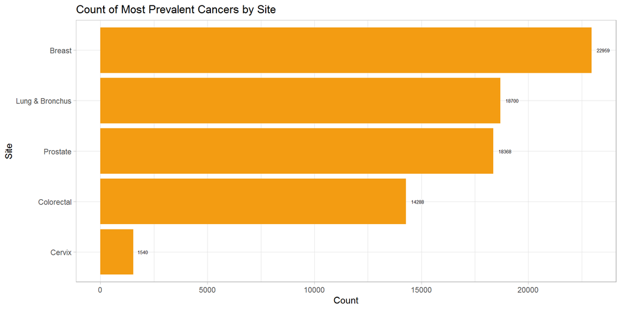

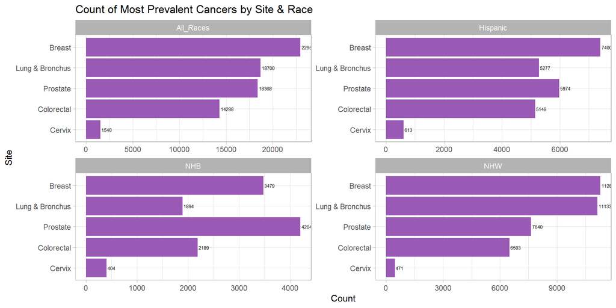

```r
library(lettercase)

makeGraphs <- function(measure, virus = FALSE) {

  measureText <- str_cap_words(measure)

  x <- prevalence %>%
    filter(sex == "P") %>%
    group_by(race) %>%
    arrange(race, .data[[measure]]) %>%
    mutate(site= factor(site, levels = unique(site), ordered = TRUE))


  if(virus == FALSE){
    f <- filter(x, race == "All_Races") %>%
      ggplot(aes_string(x = "site", y = measure))

    allcancers <- f + geom_bar(position = "dodge", stat = "identity", fill = "#2ECC71") +
      coord_flip() +
      geom_text(aes_string(label = measure), hjust = -0.4, color = "black",
                position = position_dodge(width = 1), size = 2) +
      labs(x = "Site",
           y = measureText) +
      ggtitle(paste0(measureText," of 19 Cancers by Site ")) +
      theme_light()

    # ggsave(paste0("./images/", measureText, "_allcancers.png"))

    # just breast, colorectal, lung, prostate, cervical

    x2 <- filter(x, site %in% c("Prostate", "Colorectal", "Breast", "Cervix",
                                "Lung & Bronchus"))


    g <- filter(x2, race == "All_Races") %>%
      ggplot(aes_string(x = "site", y = measure))

    topCancer <- g + geom_bar(position = "dodge", stat = "identity", fill = "#F39C12") +
      coord_flip() +
      geom_text(aes_string(label = measure), hjust = -0.4, color = "black",
                position = position_dodge(width = 1), size = 2) +
      labs(x = "Site",
           y = measureText) +
      ggtitle(paste0(measureText," of Most Prevalent Cancers by Site ")) +
      theme_light()

    # ggsave(paste0("./images/", measureText,"_topCancer.png"))

    # facet by race
    h <-  ggplot(x2, aes_string(x = "site", y = measure))

    topCancerRace <- h + geom_bar(position = "dodge", stat = "identity", fill = "#9B59B6") +
      coord_flip() +
      geom_text(aes_string(label = measure), hjust = -0.1, color = "black",
                position = position_dodge(width = 1), size = 2) +
      labs(x = "Site",
           y = measureText) +
      ggtitle(x) +
      ggtitle(paste0(measureText," of Most Prevalent Cancers by Site & Race")) +
      theme_light() +
      facet_wrap("race", scales = "free")

    # ggsave(paste0("./images/", measureText,"_topCancerRace.png"))

    list(allcancers, topCancer, topCancerRace)

  }else{
    # just cancers caused by viruses

    virus <- filter(x, site %in% c("Anal", "Non-Hodgkin Lymphoma", "Liver",
                                   "Oral & Oropharynx", "Cervix",
                                   "Stomach"))


    i <- filter(virus, race == "All_Races") %>%
      ggplot(aes_string(x = "site", y = measure))

    virusCancer <- i + geom_bar(position = "dodge", stat = "identity", fill = "#F0B27A") +
      coord_flip() +
      geom_text(aes_string(label = measure), hjust = -0.4, color = "black",
                position = position_dodge(width = 1), size = 2) +
      labs(x = "Site",
           y = measureText) +
      ggtitle(paste0(measureText," of Cancers Caused by Viruses")) +
      theme_light()

    # ggsave(paste0("./images/", measureText,"_virusCancer.png"))

    # facet by race

    i <-  ggplot(virus, aes_string(x = "site", y = measure))

    virusCancerRace <- i + geom_bar(position = "dodge", stat = "identity", fill = "#9B59B6") +
      coord_flip() +
      geom_text(aes_string(label = measure), hjust = -0.1, color = "black",
                position = position_dodge(width = 1), size = 2) +
      labs(x = "Site",
           y = measureText) +
      ggtitle(x) +
      ggtitle(paste0(measureText," of Cancers Caused by Viruses")) +
      theme_light() +
      facet_wrap("race", scales = "free")

    # ggsave(paste0("./images/", measureText,"_virusCancerRace.png"))

    list(virusCancer, virusCancerRace)
  }
}

makeGraphs("count")
```

Now, this made me excited at first *until* I noticed that when I facted by race, the order of the levels for site remained fixed, regardless of race. The order for the “All_Races” group was getting recycled. *This* is where the headache, more cursing, and thoughts of running away and never coming back started to creep in.

How can I facet on race yet still preserve the order of site per each race group???

* *In the Spongebob narrator voice* * A few hours later…. I gave up and went home.

Then in the middle of the night I awoke with an idea…as most annoying problems tend to do. Faceting fixes the y axis so I can’t use this. I will need to create 4 individual plots and join them into 1 for easier comparison.

I was advised to try `par()` or `layout()` but then learned that these functions are not compatible with ggpolot - only plot functions.

Again, there’s no way I’m going to copy and paste each ggplot code 4 times - one that filters for each race group…I feel another function coming on.

Better yet, `map()` to the rescue!

What if I listed the race categories and passed that to a map which contained a function that filtered the data by the race and drew the plot? So let’s try this one mo’gain (don’t judge, I’m a Georgia girl, born and bred).

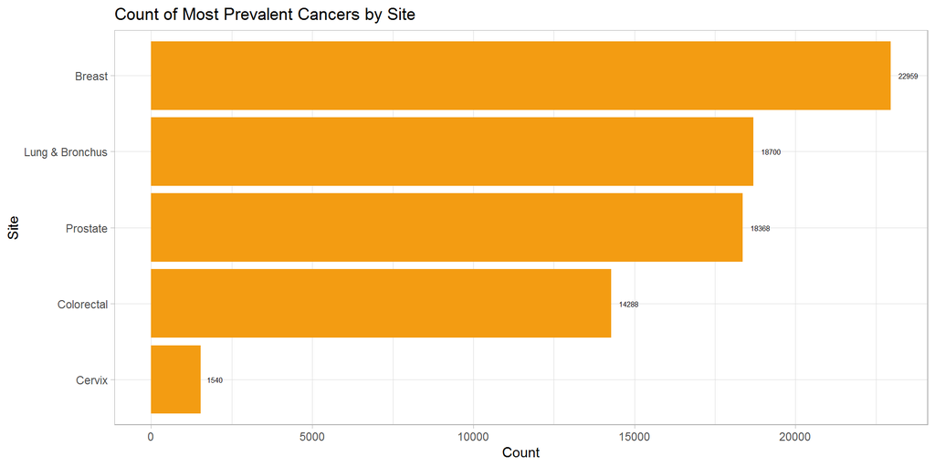

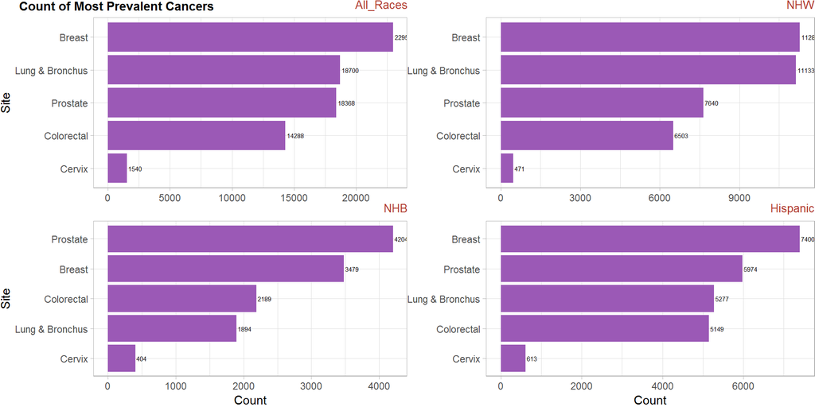

```r
library(ggpubr) # for arranging the individual race plots to one

makeGraphs <- function(measure, virus = FALSE) {

  measureText <- str_cap_words(measure)

  x <- prevalence %>%
    filter(sex == "P") %>%
    group_by(race) %>%
    arrange(race, .data[[measure]]) %>%
    mutate(site= factor(site, levels = unique(site), ordered = TRUE))


  if(virus == FALSE){
    f <-  filter(x, race == "All_Races") %>%
      ggplot(aes_string(x = "site", y = measure))

    allcancers <- f + geom_bar(position = "dodge", stat = "identity", fill = "#2ECC71") +
      coord_flip() +
      geom_text(aes_string(label = measure), hjust = -0.4, color = "black",
                position = position_dodge(width = 1), size = 2) +
      labs(x = "Site",
           y = measureText) +
      ggtitle(paste0(measureText," of 19 Cancers by Site ")) +
      theme_light()

    # ggsave(paste0("./images/", measureText, "_allcancers.png"))

    # just breast, colorectal, lung, prostate, cervical

    x2 <- filter(x, site %in% c("Prostate", "Colorectal", "Breast", "Cervix",
                                "Lung & Bronchus"))


    g <-  filter(x2, race == "All_Races") %>%
      ggplot(aes_string(x = "site", y = measure))

    topCancer <- g + geom_bar(position = "dodge", stat = "identity", fill = "#F39C12") +
      coord_flip() +
      geom_text(aes_string(label = measure), hjust = -0.4, color = "black",
                position = position_dodge(width = 1), size = 2) +
      labs(x = "Site",
           y = measureText) +
      ggtitle(paste0(measureText," of Most Prevalent Cancers by Site ")) +
      theme_light()

    # ggsave(paste0("./images/", measureText,"_topCancer.png"))

    # facet by race
    races <- list("All_Races", "NHW", "NHB", "Hispanic")

    raceGraphs <- map(races, function(x){
      h <-  x2 %>%
        filter(race == x) %>%
        arrange(race, .data[[measure]]) %>%
        mutate(site= factor(site, levels = unique(site), ordered = TRUE)) %>%
        ggplot(aes_string(x = "site", y = measure))

      h + geom_bar(position = "dodge", stat = "identity", fill = "#9B59B6") +
        coord_flip() +
        geom_text(aes_string(label = measure), hjust = -0.1, color = "black",
                  position = position_dodge(width = 1), size = 2) +
        labs(x = "Site",
             y = measureText) +
        ggtitle(x) +
        theme_light()+
        theme(plot.title = element_text(size = 10, color = "#B03A2E", hjust = 1),
              plot.margin = margin(0,0,0,0))

    })

    h <- ggarrange(
      raceGraphs[[1]] + rremove("x.title"),
      raceGraphs[[2]] + rremove("y.title") + rremove("x.title"),
      raceGraphs[[3]],
      raceGraphs[[4]] + rremove("y.title"),
      ncol = 2, nrow = 2
    )

    topCancerRace <- annotate_figure(h, fig.lab = paste0(measureText," of Most Prevalent Cancers"),
                                     fig.lab.face = "bold")

    # ggsave(paste0("./images/", measureText,"_topCancerRace.png"))

    list(allcancers, topCancer, topCancerRace)
  }else{
    # just cancers caused by viruses

    virus <- filter(x, site %in% c("Anal", "Non-Hodgkin Lymphoma", "Liver",
                                   "Oral & Oropharynx", "Cervix",
                                   "Stomach"))


    i <-  filter(virus, race == "All_Races") %>%
      ggplot(aes_string(x = "site", y = measure))

    virusCancer <- i + geom_bar(position = "dodge", stat = "identity", fill = "#F0B27A") +
      coord_flip() +
      geom_text(aes_string(label = measure), hjust = -0.4, color = "black",
                position = position_dodge(width = 1), size = 2) +
      labs(x = "Site",
           y = measureText) +
      ggtitle(paste0(measureText," of Cancers Caused by Viruses by Site")) +
      theme_light()

    # ggsave(paste0("./images/", measureText,"_virusCancer.png"))

    # facet by race
    races <- list("All_Races", "NHW", "NHB", "Hispanic")

    raceGraphs <- map(races, function(x){
      j <-  virus %>%
        filter(race == x) %>%
        arrange(race, .data[[measure]]) %>%
        mutate(site= factor(site, levels = unique(site), ordered = TRUE)) %>%
        ggplot(aes_string(x = "site", y = measure))

      j + geom_bar(position = "dodge", stat = "identity", fill = "#BB8FCE") +
        coord_flip() +
        geom_text(aes_string(label = measure), hjust = -0.1, color = "black",
                  position = position_dodge(width = 1), size = 2) +
        labs(x = "Site",
             y = measureText) +
        ggtitle(x) +
        theme_light()+
        theme(plot.title = element_text(size = 10, color = "#E74C3C", hjust = 1),
              plot.margin = margin(0,0,0,0))
    })

    j <- ggarrange(
      raceGraphs[[1]] + rremove("x.title"),
      raceGraphs[[2]] + rremove("y.title") + rremove("x.title"),
      raceGraphs[[3]],
      raceGraphs[[4]] + rremove("y.title"),
      ncol = 2, nrow = 2
    )

    virusCancerRace <- annotate_figure(j, fig.lab = paste0(measureText," of Cancers Caused by Viruses by Site"),
                                       fig.lab.face = "bold")

    # ggsave(paste0("./images/", measureText,"_virusCancerRace.png"))

    list(virusCancer, virusCancerRace)
  }


}

makeGraphs("count")
```

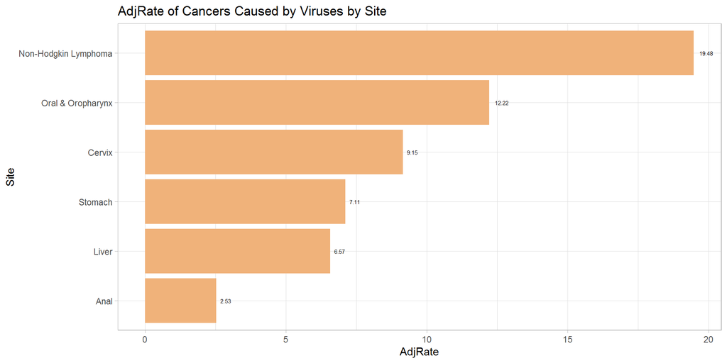

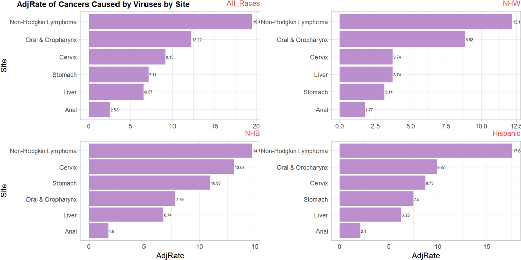

```r
makeGraphs("adjRate", virus = TRUE)
```

**YAASSSS!!!**…purrring in contentment ;)

*Note: I’ve commented out the ggsaves for the sake of making sure I don’t screw up what I already have

I hope what went through my head effectively made it through my fingers, onto the keyboard, and on the screen into this document in an intelligible way.